# Even More Linear Regression

Dr Christopher Yau

17/10/2017

# Estimating confidence intervals for linear models

Consider a linear model of the form:
$$y_i = a + bx_i + \epsilon_i$$
where $a$ is an intercept, $b$ is a slope term and $\epsilon \sim N(0, \sigma^2)$ is normally distributed noise with variance $\sigma^2$.

Lets use R to simulate some data:

```r
library(ggplot2)

a = -1
b = 0.5
sigma2 = 0.1
n = 100

x = rnorm(n, 0, 1)
e = rnorm(n, 0, sqrt(sigma2))
y = a + b*x + e
```

Now lets fit a linear model and compute the predictions:

```r
dat = data.frame(x=x, y=y)
fit = lm(y~x, dat)

a_hat = fit$coefficients[1]
b_hat = fit$coefficients[2]

dat$y_hat = a_hat + b_hat*x
```

Check the fit to see if it is OK:

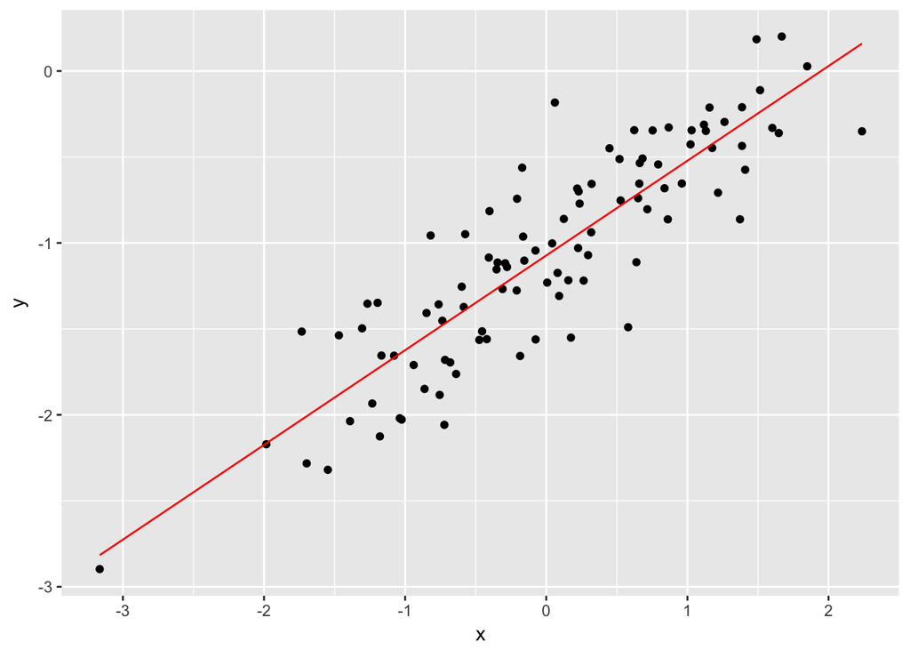

```r
plt = ggplot(dat, aes(x=x, y=y))
plt = plt + geom_point()
plt = plt + geom_line(aes(x=x, y=y_hat), colour="red")
print(plt)
```

We now want to estimate a 95% confidence interval for the slope parameter $b$. Remember, the 95% confidence interval is an interval that contains the true value of $b$ (0.5) in 95% of experiments if we were able to repeat the experiments over and over.

Lets compute this for our data:

```r
Sxx = sum(x^2)
Sx = sum(x)

s2 = var(y - fit$fitted.values)

sigma_b_hat = sqrt(s2)*sqrt(n/(n*Sxx-Sx^2))
print(sigma_b_hat)
```

```
## [1] 0.03038421
```

This is the standard error of the slope estimate for our data.

For large samples, theory tells us that the confidence interval for $b$ is given by:
$$\hat{b} \pm z_{\alpha/2} \hat{\sigma}_{\hat{b}}$$
where $z_{\alpha/2}$ is an ordinate of the standard normal distribution for the desired significance level. In this case, we want a 95% confidence interval so we require $\alpha = 1-0.95 = 0.05$ or $z_{0.025} = -1.96$.

Now, lets compute our confidence interval for our data:

```r
z = qnorm((1-0.95)/2)
b_conf_int = c( b_hat + z*sigma_b_hat, b_hat - z*sigma_b_hat  )

print(b_conf_int)
```

```
##         x         x
## 0.4914107 0.6105146
```

## Deriving the confidence interval by simulation

Lets check if the theory is correct using simulations. Lets write a loop to simulate 10,000 data sets (we will keep the same $x$’s) and fit a linear model each time to get estimates of the slope parameter:

```r
n_its = 10000 # number of loops
b_hat_all = rep(0, n_its) # store my slope estimates here
for ( it in 1:n_its ){
  e = rnorm(n, 0, sqrt(sigma2)) # generate noise
  y_new = a + b*x + e # compute y's
  dat = data.frame(x=x, y=y_new) # set up data frame
  fit_new = lm(y~x, dat) # fit lm
  b_hat = fit_new$coefficients[2] # extract slope parameter estimate
  b_hat_all[it] = b_hat # store
}
```

Lets draw a histogram of the slope estimates:

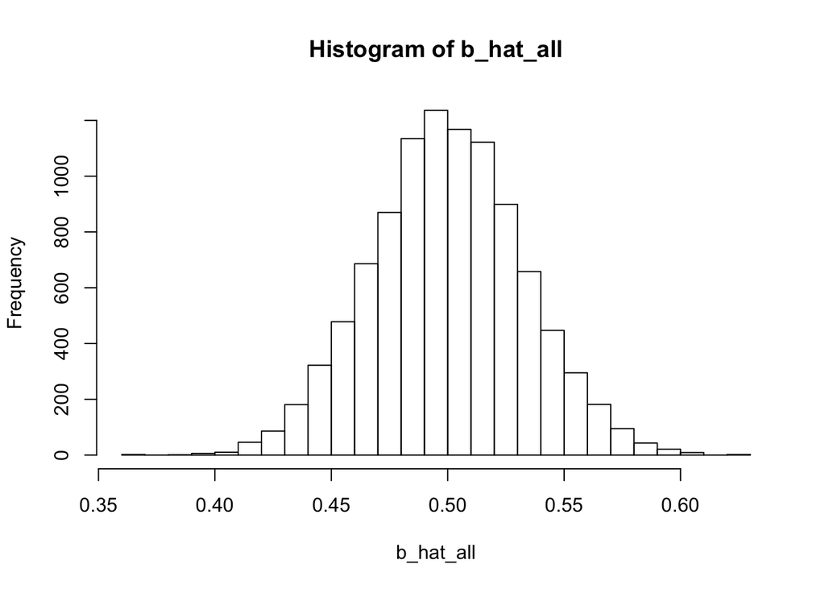

```r
hist(b_hat_all, 30)
```

```r
print(mean(b_hat_all))
```

```
## [1] 0.4998268
```

```r
print(sd(b_hat_all))
```

```
## [1] 0.03268663
```

It is normally distributed with mean 0.5 and standard deviation 0.032 is close to what we computed above for the standard error $\hat{\sigma}_{\hat{b}}$! The sampling distribution of $b$ does seem to fit the theory!

Now, lets think about the confidence intervals. First, set up a vector to consider a range of confidence interval widths. We will use 100 widths between 0.5 and 2 times the standard deviation of the slope parameters I have estimated:

```r
widths = seq(from=0.5, to=2.0, length=100)*sd(b_hat_all)
n_widths = length(widths)
```

Now, for each width, I am going to create an interval centred on the values of $\hat{b}$ I have computed and count how many times in those 10,000 simulations the true value of $b$ (0.5) falls in that interval:

```r
contained_in_interval = rep(0, n_widths)
for ( wi in 1:n_widths) {
  interval_width = widths[wi]
  lower_limit = b_hat_all-interval_width # lower limit of interval
  upper_limit = b_hat_all+interval_width # upper limit of interval
  contained_in_interval[wi] = sum( ( lower_limit < b ) & ( upper_limit > b ) ) # is the true value in the interval? how many?
}
```

Now, lets plot the frequency with which each confidence interval width contains the true values

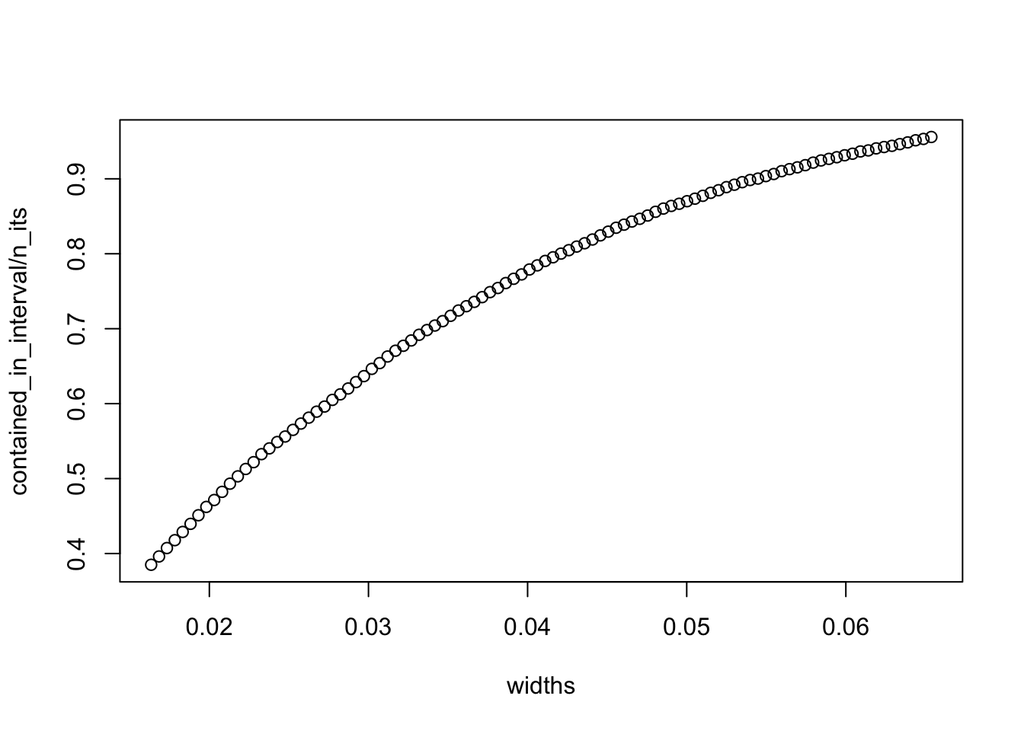

```r
plot( widths, contained_in_interval/n_its )
```

What is the 95% confidence intervals width? What was that value of $z_{\alpha/2} \hat{\sigma}_{\hat{b}}$ again?

```r
print(abs(z*sigma_b_hat))
```

```
## [1] 0.05955196
```

Of course, we could have done this all using R’s built-in function `confint`!

```r
confint(fit, level=0.95)
```

```
##                  2.5 %    97.5 %
## (Intercept) -1.1322143 -1.013333
## x            0.4903593  0.611566
```